# Correction TD3

Pierre-O Goffard

17 janvier 2019

## TD 3

### Exercice 1

#### 1)

On va utiliser le jeu de données **nycflights13**

```r
library(nycflights13)
library(tidyverse)
data(flights)
```

Trouver tout les vols - ayant eu plus de deux heures de retard - vers Houston (`IAH` ou `HOU`), on utilisera l’opérateur `%in%` - opérés durant l’été (Juillet, Aout, Septembre) - ayant eu plus de deux heures de retards mais sans retard au départ - Ont décollé entre minuit et 6 heure du matin

```r
# Vols avec plus de deux heures de retard
flights %>% filter(arr_delay /60 > 2) %>% select(arr_delay)
```

```
## # A tibble: 10,034 x 1
##    arr_delay
##        <dbl>
##  1       137
##  2       851
##  3       123
##  4       145
##  5       127
##  6       125
##  7       136
##  8       123
##  9       123
## 10       138
## # ... with 10,024 more rows
```

```r
# Vols vers Houston
flights %>% filter(dest %in% c('IAH', 'HOU')) %>% select(dest)
```

```
## # A tibble: 9,313 x 1
##    dest
##    <chr>
##  1 IAH
##  2 IAH
##  3 IAH
##  4 IAH
##  5 IAH
##  6 IAH
##  7 IAH
##  8 IAH
##  9 IAH
## 10 IAH
## # ... with 9,303 more rows
```

```r
#Vols d'été
flights %>% filter(month >= 7 & month <= 9) %>% select(month)
```

```
## # A tibble: 86,326 x 1
##    month
##    <int>
##  1     7
##  2     7
##  3     7
##  4     7
##  5     7
##  6     7
##  7     7
##  8     7
##  9     7
## 10     7
## # ... with 86,316 more rows
```

```r
#Vols ayant eu plus de deux heures de retards mais sans retard au départ
flights %>% filter(dep_delay == 0 & arr_delay /60 > 2) %>% select(dep_delay, arr_delay)
```

```
## # A tibble: 3 x 2
##   dep_delay arr_delay
##       <dbl>     <dbl>
## 1         0       130
## 2         0       128
## 3         0       140
```

```r
# Vols ayant décollé entre minuit et 6 heures du matin inclus
flights %>% filter(floor(dep_time / 100) < 6 | dep_time == 600) %>% select(dep_time)
```

```
## # A tibble: 9,344 x 1
##    dep_time
##       <int>
##  1      517
##  2      533
##  3      542
##  4      544
##  5      554
##  6      554
##  7      555
##  8      557
##  9      557
## 10      558
## # ... with 9,334 more rows
```

### 2)

Fusionner les tables `flights` et `airlines`, ne conserver que les variables `òrigin, dest, name`, et `carrier` et les vols par United, American ou Delta airline. Utiliser un *pipe* pour accomplir ces actions, et l’opérateur `like` pour la sélection des observations.

```r
library(DescTools)
left_join(flights, airlines, by = 'carrier') %>% select(origin, dest, carrier, name) %>% filter(name %like% "United%" | name %like% "American%" | name %like% "Delta%")
```

```
## # A tibble: 139,504 x 4
##    origin dest  carrier name
##    <chr>  <chr> <chr>   <chr>
##  1 EWR    IAH   UA      United Air Lines Inc.
##  2 LGA    IAH   UA      United Air Lines Inc.
##  3 JFK    MIA   AA      American Airlines Inc.
##  4 LGA    ATL   DL      Delta Air Lines Inc.
##  5 EWR    ORD   UA      United Air Lines Inc.
##  6 LGA    ORD   AA      American Airlines Inc.
##  7 JFK    LAX   UA      United Air Lines Inc.
##  8 EWR    SFO   UA      United Air Lines Inc.
##  9 LGA    DFW   AA      American Airlines Inc.
## 10 EWR    LAS   UA      United Air Lines Inc.
## # ... with 139,494 more rows
```

### 3)

Créer une table `flights_V1` à partir de la table `flights` en ajoutant une variable permettant le calcul du temps rattrapé en vol, puis sélectionner les vols qui sont partis avec au moins une heure de retard mais sont parvenu à récupéré plus de 30 minutes durant le vol. N’inclure que les variables `origin, dest, carrier, dep_delay, distance` ainsi que la nouvelle variable. Afficher les cinq premières observations de `flights_V1`, copier et coller le tableau.

```r
library(knitr)

flights_V1 <- flights %>% mutate(
  in_flight = dep_delay - arr_delay
) %>% filter(dep_delay / 60 > 1 & in_flight > 30) %>% select(origin, dest, carrier, dep_delay, in_flight, distance)
kable(flights_V1[1:5, ])
```

| origin | dest | carrier | dep_delay | in_flight | distance |
| --- | --- | --- | --- | --- | --- |
| EWR | MIA | AA | 285 | 39 | 1085 |
| JFK | LAS | B6 | 116 | 43 | 2248 |
| EWR | SFO | UA | 162 | 34 | 2565 |
| JFK | EGE | AA | 99 | 33 | 1747 |
| JFK | SFO | AA | 65 | 37 | 2586 |

```r
flights_V1[1:5, ]
```

```
## # A tibble: 5 x 6
##   origin dest  carrier dep_delay in_flight distance
##   <chr>  <chr> <chr>       <dbl>     <dbl>    <dbl>
## 1 EWR    MIA   AA            285        39     1085
## 2 JFK    LAS   B6            116        43     2248
## 3 EWR    SFO   UA            162        34     2565
## 4 JFK    EGE   AA             99        33     1747
## 5 JFK    SFO   AA             65        37     2586
```

### 4)

Trier `flights` du vol avec le plus de retard au départ au vols ayant le moins de retard (voire de l’avance), n’inclure que les variables `carrier, origin, dest` et `dep_delay`.

```r
flights %>% arrange(desc(dep_delay)) %>% select(carrier, origin, dest, dep_delay)
```

```
## # A tibble: 336,776 x 4
##    carrier origin dest  dep_delay
##    <chr>   <chr>  <chr>     <dbl>
##  1 HA      JFK    HNL        1301
##  2 MQ      JFK    CMH        1137
##  3 MQ      EWR    ORD        1126
##  4 AA      JFK    SFO        1014
##  5 MQ      JFK    CVG        1005
##  6 DL      JFK    TPA         960
##  7 DL      LGA    MSP         911
##  8 DL      JFK    PDX         899
##  9 DL      LGA    ATL         898
## 10 AA      EWR    MIA         896
## # ... with 336,766 more rows
```

### 5)

Créer la table `flights_V2` à partir de `flights` dans laquelle les variables `dep_time` et `sched_dep_time` en nombre de minutes depuis minuit. N’inclure que les variables `dep_time, sched_dep_time` et les deux nouvelles variables qu’on appellera `dep_time_V1`et `sched_dep_time_V1`. Afficher les 5 première observations en utilisant  
`kable()` pour copier et coller votre tableau, pas de code R.

```r
flights_V2 <- flights %>% mutate(
  dep_time_V1 = floor(dep_time / 100) * 60 + (dep_time -   floor(dep_time / 100) * 100),
  sched_dep_time_V1 = floor(sched_dep_time / 100) * 60 + (sched_dep_time -   floor(sched_dep_time / 100) * 100)
  ) %>% select(dep_time, dep_time_V1, sched_dep_time, sched_dep_time_V1)
flights_V2[1:5, ]
```

```
## # A tibble: 5 x 4
##   dep_time dep_time_V1 sched_dep_time sched_dep_time_V1
##      <int>       <dbl>          <int>             <dbl>
## 1      517         317            515               315
## 2      533         333            529               329
## 3      542         342            540               340
## 4      544         344            545               345
## 5      554         354            600               360
```

### 6)

Créer une table `average_delay` donnant le retard moyen à l’arrivées des vols et le nombre de vols pour chaque mois. Tracer le retard moyen en fonction du mois de l’année.

- Le graphique doit être un nuage de point pondéré par le nombre de vol.
- Donner un nom à l’axe des abscisses et des ordonnées.
- Faites en sorte que la graduation de l’axe des x fasse bien apparaître chaque mois.
- Ajouter la droite x = 0 comme ligne horizontale de référence

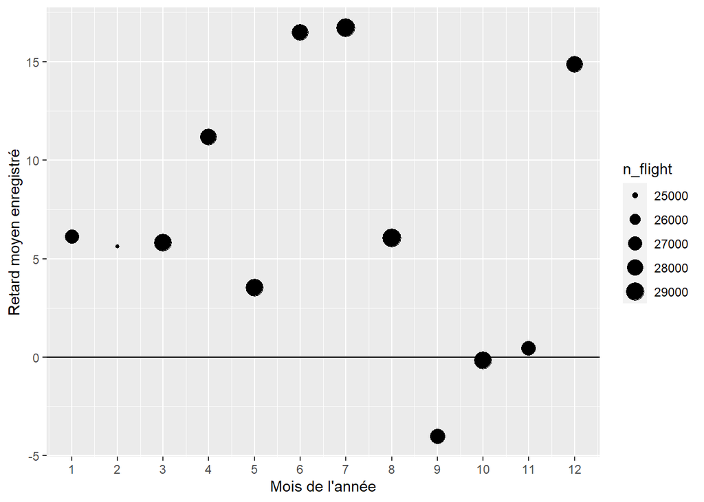

```r
average_delay <- group_by(flights, month) %>%
  summarise(n_flight = n(), av_delay = mean(arr_delay, na.rm = T))
  ggplot(data = average_delay) + geom_point(mapping = aes(x = month, y = av_delay, size = n_flight)) + xlab("Mois de l'année") + ylab("Retard moyen enregistré") + geom_hline(yintercept = 0) + scale_x_continuous(breaks = 1:12)
```

### 7) Créer une table `average_daily_America_United` qui donne le retard moyen à l’arrivée des vols et le nombre de vols pour chaque jour des compagnies *American* et *United airline*. Tracer le retard moyen en fonction du jour de l’année pour les deux compagnies, le jour de l’année doit être donné par une variable `date_dep` sous le format `Date`. Le graphique doit contenir la courbe associée à chacune des compagnies, utiliser la fonction **geom_smooth** afin de lisser les courbes. Coller simplement l’image, pas de code R.

```r
library(DescTools)
average_daily_America_United <- left_join(flights, airlines, by = 'carrier') %>%
  filter(name %like% 'American%' | name %like% 'United%') %>%
  mutate(date_dep = as.Date(paste0(day, '/', month, '/', year), format = '%d/%m/%Y')) %>%
  group_by(date_dep, name) %>%
  summarise(average_daily_delay = mean(arr_delay, na.rm = T))
```

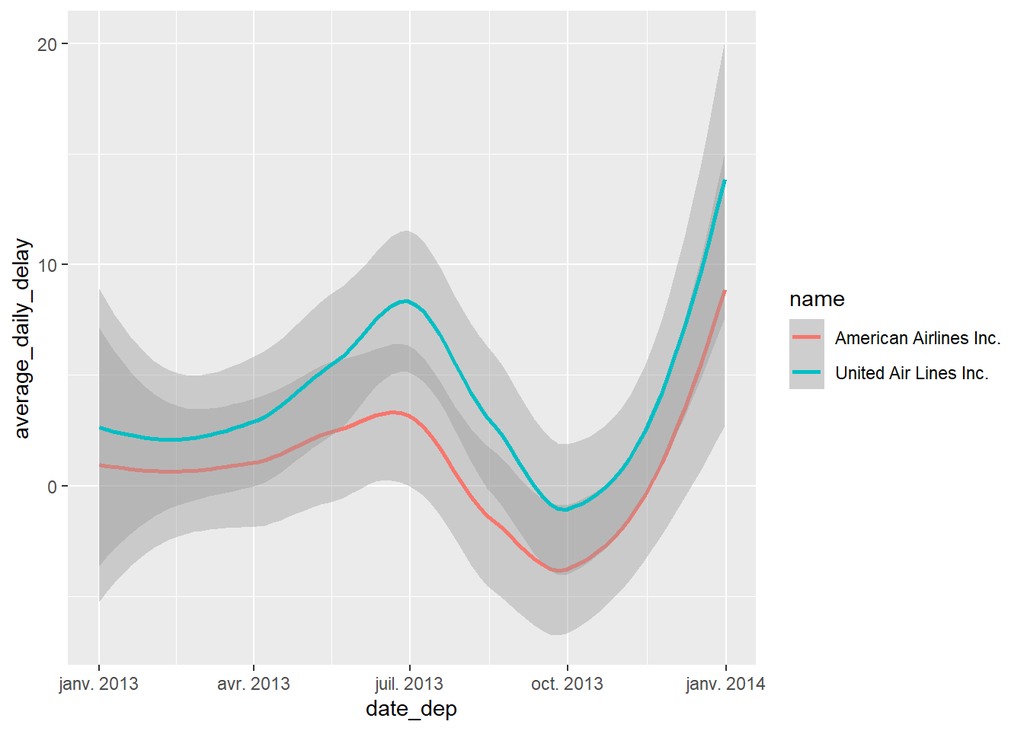

```r
ggplot(data = average_daily_America_United, mapping = aes(x = date_dep, y = average_daily_delay, colour = name)) + geom_smooth()
```

### 8) On souhaite créer un tableau contenant le pourcentage de vol en retard par combinaison compagnie aérienne / aéroport de départ. Créer la table `worst_delay` contenant les variables `carrier, origin, number_delay, number_flight` et `prop_delay`. La table donne pour chaque combinaison de modalité sur les variables `carrier` et `origin`:

- le nombre de vol en retard `number_delay`
- le nombre de vol total `number_flight
- la proportion de vol en retard `prop_delay`

Trier la table suivant la variable `prop_delay` de façon à afficher d’abord les combinaisons compagnie aérienne / aéroport de départ ayant la plus grande proportion de vol en retard. Afficher les cinq premières observations de `worst_delay`.

```r
worst_delay <- left_join(
  flights %>% mutate(delaid = arr_delay > 0) %>% group_by(carrier, origin, delaid) %>% summarize(number_delay = n()) %>% filter(!is.na(delaid)),
  flights %>% group_by(carrier, origin) %>% summarize(number_flight = n()), by = c('carrier', 'origin')) %>% mutate(prop_delay = number_delay / number_flight) %>% arrange(desc(prop_delay)) %>% select(-delaid)
worst_delay[1:5, ]
```

```
## # A tibble: 5 x 5
## # Groups:   carrier, origin [5]
##   carrier origin number_delay number_flight prop_delay
##   <chr>   <chr>         <int>         <int>      <dbl>
## 1 AS      EWR             520           714      0.728
## 2 HA      JFK             245           342      0.716
## 3 DL      JFK           14206         20701      0.686
## 4 VX      EWR            1070          1566      0.683
## 5 OO      EWR               4             6      0.667
```